# Risk Factor Analysis

## Outcome Variable

**Outcome Variable:** haz

## Predictor Variables

**Intervention Variable:** birthlen

**Adjustment Set:**

unadjusted

## Stratifying Variables

The analysis was stratified on these variable(s):

- agecat
- studyid
- country

## Data Summary

| agecat | studyid | country | birthlen | n_cell | n |
| --- | --- | --- | --- | --- | --- |
| Birth | CMC-V-BCS-2002 | INDIA | >=50 cm | 14 | 92 |
| Birth | CMC-V-BCS-2002 | INDIA | <48 cm | 38 | 92 |
| Birth | CMC-V-BCS-2002 | INDIA | [48-50) cm | 40 | 92 |
| Birth | CMIN | BANGLADESH | >=50 cm | 2 | 26 |
| Birth | CMIN | BANGLADESH | <48 cm | 16 | 26 |
| Birth | CMIN | BANGLADESH | [48-50) cm | 8 | 26 |
| Birth | COHORTS | GUATEMALA | >=50 cm | 437 | 852 |
| Birth | COHORTS | GUATEMALA | <48 cm | 163 | 852 |
| Birth | COHORTS | GUATEMALA | [48-50) cm | 252 | 852 |
| Birth | COHORTS | INDIA | >=50 cm | 1426 | 6640 |
| Birth | COHORTS | INDIA | <48 cm | 2774 | 6640 |
| Birth | COHORTS | INDIA | [48-50) cm | 2440 | 6640 |
| Birth | COHORTS | PHILIPPINES | >=50 cm | 1129 | 3050 |
| Birth | COHORTS | PHILIPPINES | <48 cm | 762 | 3050 |
| Birth | COHORTS | PHILIPPINES | [48-50) cm | 1159 | 3050 |
| Birth | CONTENT | PERU | >=50 cm | 1 | 2 |
| Birth | CONTENT | PERU | <48 cm | 1 | 2 |
| Birth | CONTENT | PERU | [48-50) cm | 0 | 2 |
| Birth | EE | PAKISTAN | >=50 cm | 24 | 240 |
| Birth | EE | PAKISTAN | <48 cm | 162 | 240 |
| Birth | EE | PAKISTAN | [48-50) cm | 54 | 240 |
| Birth | GMS-Nepal | NEPAL | >=50 cm | 115 | 696 |
| Birth | GMS-Nepal | NEPAL | <48 cm | 373 | 696 |
| Birth | GMS-Nepal | NEPAL | [48-50) cm | 208 | 696 |
| Birth | IRC | INDIA | >=50 cm | 142 | 388 |
| Birth | IRC | INDIA | <48 cm | 108 | 388 |
| Birth | IRC | INDIA | [48-50) cm | 138 | 388 |
| Birth | Keneba | GAMBIA | >=50 cm | 763 | 1543 |
| Birth | Keneba | GAMBIA | <48 cm | 285 | 1543 |
| Birth | Keneba | GAMBIA | [48-50) cm | 495 | 1543 |

[output cut: 180 more lines]

The following strata were considered:

- agecat: 24 months, studyid: CMC-V-BCS-2002, country: INDIA
- agecat: 24 months, studyid: CMIN, country: BANGLADESH
- agecat: 24 months, studyid: COHORTS, country: GUATEMALA
- agecat: 24 months, studyid: COHORTS, country: INDIA
- agecat: 24 months, studyid: COHORTS, country: PHILIPPINES
- agecat: 24 months, studyid: CONTENT, country: PERU
- agecat: 24 months, studyid: EE, country: PAKISTAN
- agecat: 24 months, studyid: GMS-Nepal, country: NEPAL
- agecat: 24 months, studyid: IRC, country: INDIA
- agecat: 24 months, studyid: Keneba, country: GAMBIA
- agecat: 24 months, studyid: MAL-ED, country: BANGLADESH
- agecat: 24 months, studyid: MAL-ED, country: BRAZIL
- agecat: 24 months, studyid: MAL-ED, country: INDIA
- agecat: 24 months, studyid: MAL-ED, country: NEPAL
- agecat: 24 months, studyid: MAL-ED, country: PERU
- agecat: 24 months, studyid: MAL-ED, country: SOUTH AFRICA
- agecat: 24 months, studyid: MAL-ED, country: TANZANIA, UNITED REPUBLIC OF
- agecat: 24 months, studyid: NIH-Birth, country: BANGLADESH
- agecat: 24 months, studyid: NIH-Crypto, country: BANGLADESH
- agecat: 24 months, studyid: PROBIT, country: BELARUS
- agecat: 24 months, studyid: PROVIDE, country: BANGLADESH
- agecat: 24 months, studyid: ZVITAMBO, country: ZIMBABWE
- agecat: 6 months, studyid: CMC-V-BCS-2002, country: INDIA
- agecat: 6 months, studyid: CMIN, country: BANGLADESH
- agecat: 6 months, studyid: COHORTS, country: GUATEMALA
- agecat: 6 months, studyid: COHORTS, country: INDIA
- agecat: 6 months, studyid: COHORTS, country: PHILIPPINES
- agecat: 6 months, studyid: CONTENT, country: PERU
- agecat: 6 months, studyid: EE, country: PAKISTAN
- agecat: 6 months, studyid: GMS-Nepal, country: NEPAL
- agecat: 6 months, studyid: IRC, country: INDIA
- agecat: 6 months, studyid: Keneba, country: GAMBIA
- agecat: 6 months, studyid: MAL-ED, country: BANGLADESH
- agecat: 6 months, studyid: MAL-ED, country: BRAZIL
- agecat: 6 months, studyid: MAL-ED, country: INDIA
- agecat: 6 months, studyid: MAL-ED, country: NEPAL
- agecat: 6 months, studyid: MAL-ED, country: PERU
- agecat: 6 months, studyid: MAL-ED, country: SOUTH AFRICA
- agecat: 6 months, studyid: MAL-ED, country: TANZANIA, UNITED REPUBLIC OF
- agecat: 6 months, studyid: NIH-Birth, country: BANGLADESH
- agecat: 6 months, studyid: NIH-Crypto, country: BANGLADESH
- agecat: 6 months, studyid: PROBIT, country: BELARUS
- agecat: 6 months, studyid: PROVIDE, country: BANGLADESH
- agecat: 6 months, studyid: ResPak, country: PAKISTAN
- agecat: 6 months, studyid: SAS-CompFeed, country: INDIA
- agecat: 6 months, studyid: ZVITAMBO, country: ZIMBABWE
- agecat: Birth, studyid: CMC-V-BCS-2002, country: INDIA
- agecat: Birth, studyid: CMIN, country: BANGLADESH
- agecat: Birth, studyid: COHORTS, country: GUATEMALA
- agecat: Birth, studyid: COHORTS, country: INDIA
- agecat: Birth, studyid: COHORTS, country: PHILIPPINES
- agecat: Birth, studyid: CONTENT, country: PERU
- agecat: Birth, studyid: EE, country: PAKISTAN
- agecat: Birth, studyid: GMS-Nepal, country: NEPAL
- agecat: Birth, studyid: IRC, country: INDIA
- agecat: Birth, studyid: Keneba, country: GAMBIA
- agecat: Birth, studyid: MAL-ED, country: BANGLADESH
- agecat: Birth, studyid: MAL-ED, country: BRAZIL
- agecat: Birth, studyid: MAL-ED, country: INDIA
- agecat: Birth, studyid: MAL-ED, country: NEPAL
- agecat: Birth, studyid: MAL-ED, country: PERU
- agecat: Birth, studyid: MAL-ED, country: SOUTH AFRICA
- agecat: Birth, studyid: MAL-ED, country: TANZANIA, UNITED REPUBLIC OF
- agecat: Birth, studyid: NIH-Birth, country: BANGLADESH
- agecat: Birth, studyid: NIH-Crypto, country: BANGLADESH
- agecat: Birth, studyid: PROBIT, country: BELARUS
- agecat: Birth, studyid: PROVIDE, country: BANGLADESH
- agecat: Birth, studyid: ResPak, country: PAKISTAN
- agecat: Birth, studyid: SAS-CompFeed, country: INDIA
- agecat: Birth, studyid: ZVITAMBO, country: ZIMBABWE

### Dropped Strata

Some strata were dropped due to rare outcomes:

- agecat: Birth, studyid: CMIN, country: BANGLADESH
- agecat: Birth, studyid: CONTENT, country: PERU
- agecat: 6 months, studyid: CMIN, country: BANGLADESH
- agecat: 6 months, studyid: CONTENT, country: PERU
- agecat: 24 months, studyid: CMIN, country: BANGLADESH
- agecat: 24 months, studyid: CONTENT, country: PERU

## Methods Detail

We’re interested in the causal parameters $E[Y_a]$ for all values of $a \in \mathcal{A}$. These parameters represent the mean outcome if, possibly contrary to fact, we intervened to set all units to have $A=a$. Under the randomization and positivity assumptions, these are identified by the statistical parameters $\psi_a=E_W[E_{Y|A,W}(Y|A=a,W)]$. In addition, we’re interested in the mean of $Y$, $E[Y]$ under no intervention (the observed mean). We will estimate these parameters by using SuperLearner to fit the relevant likelihood factors – $E_{Y|A,W}(Y|A=a,W)$ and $p(A=a|W)$, and then updating our likelihood fit using a joint TMLE.

For unadjusted analyses ($W=\{\}$), initial likelihoods were estimated using Lrnr_glm to estimate the simple $E(Y|A)$ and Lrnr_mean to estimate $p(A)$. For adjusted analyses, a small library containing Lrnr_glmnet, Lrnr_xgboost, and Lrnr_mean was used.

Having estimated these parameters, we will then use the delta method to estimate relative risks and attributable risks relative to a prespecified baseline level of $A$.

# Results Detail

## Results Plots

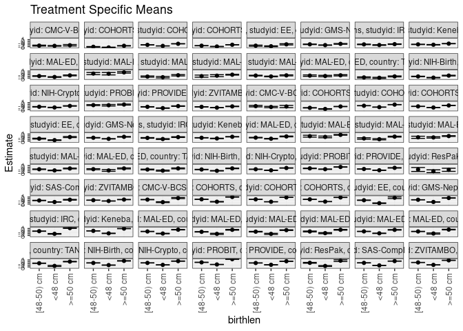

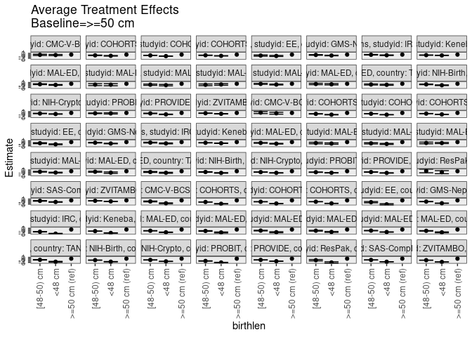

[figure not shown]

## Results Table

### Parameter: TSM

| agecat | studyid | country | intervention_level | baseline_level | estimate | ci_lower | ci_upper |
| --- | --- | --- | --- | --- | --- | --- | --- |
| Birth | CMC-V-BCS-2002 | INDIA | >=50 cm | NA | 0.4042857 | 0.1125279 | 0.6960435 |
| Birth | CMC-V-BCS-2002 | INDIA | <48 cm | NA | -1.9588158 | -2.1996120 | -1.7180195 |
| Birth | CMC-V-BCS-2002 | INDIA | [48-50) cm | NA | -0.4913750 | -0.5841571 | -0.3985929 |
| Birth | COHORTS | GUATEMALA | >=50 cm | NA | 1.0549199 | 0.9909325 | 1.1189074 |
| Birth | COHORTS | GUATEMALA | <48 cm | NA | -1.7085890 | -1.8444747 | -1.5727033 |
| Birth | COHORTS | GUATEMALA | [48-50) cm | NA | -0.2855952 | -0.3284090 | -0.2427815 |
| Birth | COHORTS | INDIA | >=50 cm | NA | 0.8115007 | 0.7774854 | 0.8455160 |
| Birth | COHORTS | INDIA | <48 cm | NA | -1.7220476 | -1.7513216 | -1.6927736 |
| Birth | COHORTS | INDIA | [48-50) cm | NA | -0.3394877 | -0.3534999 | -0.3254755 |
| Birth | COHORTS | PHILIPPINES | >=50 cm | NA | 0.7837644 | 0.7490377 | 0.8184911 |
| Birth | COHORTS | PHILIPPINES | <48 cm | NA | -1.6453543 | -1.6997943 | -1.5909144 |
| Birth | COHORTS | PHILIPPINES | [48-50) cm | NA | -0.3371096 | -0.3569020 | -0.3173172 |
| Birth | EE | PAKISTAN | >=50 cm | NA | 0.6241667 | 0.1420752 | 1.1062581 |
| Birth | EE | PAKISTAN | <48 cm | NA | -2.5666049 | -2.7367151 | -2.3964948 |
| Birth | EE | PAKISTAN | [48-50) cm | NA | -0.8481481 | -0.9519198 | -0.7443764 |
| Birth | GMS-Nepal | NEPAL | >=50 cm | NA | 0.4622609 | 0.3731026 | 0.5514192 |
| Birth | GMS-Nepal | NEPAL | <48 cm | NA | -1.8519303 | -1.9265325 | -1.7773281 |
| Birth | GMS-Nepal | NEPAL | [48-50) cm | NA | -0.5656731 | -0.6146244 | -0.5167218 |
| Birth | IRC | INDIA | >=50 cm | NA | 1.2693662 | 1.0895286 | 1.4492038 |
| Birth | IRC | INDIA | <48 cm | NA | -2.0878704 | -2.2886923 | -1.8870484 |
| Birth | IRC | INDIA | [48-50) cm | NA | -0.5382609 | -0.5948971 | -0.4816246 |
| Birth | Keneba | GAMBIA | >=50 cm | NA | 0.9661730 | 0.9116866 | 1.0206594 |
| Birth | Keneba | GAMBIA | <48 cm | NA | -1.8075965 | -1.9252826 | -1.6899104 |
| Birth | Keneba | GAMBIA | [48-50) cm | NA | -0.3525152 | -0.3839085 | -0.3211218 |
| Birth | MAL-ED | BANGLADESH | >=50 cm | NA | 0.3320513 | 0.2065066 | 0.4575960 |
| Birth | MAL-ED | BANGLADESH | <48 cm | NA | -1.9133628 | -2.0531367 | -1.7735890 |
| Birth | MAL-ED | BANGLADESH | [48-50) cm | NA | -0.6964557 | -0.7811379 | -0.6117735 |
| Birth | MAL-ED | BRAZIL | >=50 cm | NA | 0.2746667 | 0.0721200 | 0.4772133 |
| Birth | MAL-ED | BRAZIL | <48 cm | NA | -2.1111765 | -2.4492527 | -1.7731002 |
| Birth | MAL-ED | BRAZIL | [48-50) cm | NA | -0.9050000 | -1.0428137 | -0.7671863 |

[output cut: 162 more lines]

### Parameter: E(Y)

| agecat | studyid | country | intervention_level | baseline_level | estimate | ci_lower | ci_upper |
| --- | --- | --- | --- | --- | --- | --- | --- |
| Birth | CMC-V-BCS-2002 | INDIA | NA | NA | -0.9611957 | -1.1776967 | -0.7446946 |
| Birth | COHORTS | GUATEMALA | NA | NA | 0.1297300 | 0.0458017 | 0.2136584 |
| Birth | COHORTS | INDIA | NA | NA | -0.6698961 | -0.6980556 | -0.6417365 |
| Birth | COHORTS | PHILIPPINES | NA | NA | -0.2490492 | -0.2880580 | -0.2100404 |
| Birth | EE | PAKISTAN | NA | NA | -1.8608750 | -2.0482045 | -1.6735455 |
| Birth | GMS-Nepal | NEPAL | NA | NA | -1.0851580 | -1.1651811 | -1.0051350 |
| Birth | IRC | INDIA | NA | NA | -0.3080412 | -0.4687931 | -0.1472894 |
| Birth | Keneba | GAMBIA | NA | NA | 0.0308036 | -0.0328378 | 0.0944451 |
| Birth | MAL-ED | BANGLADESH | NA | NA | -1.1180952 | -1.2525408 | -0.9836496 |
| Birth | MAL-ED | BRAZIL | NA | NA | -0.6760000 | -0.9521457 | -0.3998543 |
| Birth | MAL-ED | INDIA | NA | NA | -1.2036170 | -1.4976814 | -0.9095527 |
| Birth | MAL-ED | NEPAL | NA | NA | -0.8533333 | -1.2104864 | -0.4961803 |
| Birth | MAL-ED | PERU | NA | NA | -0.8827897 | -1.0001058 | -0.7654736 |
| Birth | MAL-ED | SOUTH AFRICA | NA | NA | -0.6317073 | -0.8249555 | -0.4384591 |
| Birth | MAL-ED | TANZANIA, UNITED REPUBLIC OF | NA | NA | -1.1556000 | -1.3655361 | -0.9456639 |
| Birth | NIH-Birth | BANGLADESH | NA | NA | -0.9310197 | -1.0197391 | -0.8423003 |
| Birth | NIH-Crypto | BANGLADESH | NA | NA | -0.9094945 | -0.9809370 | -0.8380521 |
| Birth | PROBIT | BELARUS | NA | NA | 1.3114417 | 1.1524752 | 1.4704082 |
| Birth | PROVIDE | BANGLADESH | NA | NA | -0.8851020 | -0.9601332 | -0.8100709 |
| Birth | ResPak | PAKISTAN | NA | NA | -0.9800000 | -1.4086438 | -0.5513562 |
| Birth | SAS-CompFeed | INDIA | NA | NA | -1.4314217 | -1.5099245 | -1.3529189 |
| Birth | ZVITAMBO | ZIMBABWE | NA | NA | -0.5002724 | -0.5208163 | -0.4797285 |
| 6 months | CMC-V-BCS-2002 | INDIA | NA | NA | -1.2953686 | -1.5534398 | -1.0372973 |
| 6 months | COHORTS | GUATEMALA | NA | NA | -1.7553052 | -1.8330182 | -1.6775923 |
| 6 months | COHORTS | INDIA | NA | NA | -0.9973610 | -1.0266429 | -0.9680792 |
| 6 months | COHORTS | PHILIPPINES | NA | NA | -1.1429137 | -1.1848624 | -1.1009651 |
| 6 months | EE | PAKISTAN | NA | NA | -2.1264619 | -2.2795142 | -1.9734095 |
| 6 months | GMS-Nepal | NEPAL | NA | NA | -1.3510539 | -1.4294158 | -1.2726919 |
| 6 months | IRC | INDIA | NA | NA | -1.2263582 | -1.3620220 | -1.0906944 |
| 6 months | Keneba | GAMBIA | NA | NA | -0.9034101 | -0.9602836 | -0.8465366 |
| 6 months | MAL-ED | BANGLADESH | NA | NA | -1.2087678 | -1.3332048 | -1.0843307 |
| 6 months | MAL-ED | BRAZIL | NA | NA | 0.0564689 | -0.1983718 | 0.3113097 |
| 6 months | MAL-ED | INDIA | NA | NA | -1.5092276 | -1.7906712 | -1.2277841 |
| 6 months | MAL-ED | NEPAL | NA | NA | -0.6684615 | -0.9484552 | -0.3884679 |
| 6 months | MAL-ED | PERU | NA | NA | -1.2930271 | -1.4141974 | -1.1718569 |
| 6 months | MAL-ED | SOUTH AFRICA | NA | NA | -1.0985125 | -1.3092915 | -0.8877336 |
| 6 months | MAL-ED | TANZANIA, UNITED REPUBLIC OF | NA | NA | -1.3305226 | -1.5032169 | -1.1578283 |
| 6 months | NIH-Birth | BANGLADESH | NA | NA | -1.4092745 | -1.5003907 | -1.3181582 |
| 6 months | NIH-Crypto | BANGLADESH | NA | NA | -1.1986783 | -1.2700937 | -1.1272630 |
| 6 months | PROBIT | BELARUS | NA | NA | 0.0980074 | 0.0062724 | 0.1897424 |
| 6 months | PROVIDE | BANGLADESH | NA | NA | -1.0916915 | -1.1661176 | -1.0172654 |
| 6 months | ResPak | PAKISTAN | NA | NA | -1.7077451 | -2.2839081 | -1.1315821 |
| 6 months | SAS-CompFeed | INDIA | NA | NA | -1.4030363 | -1.4821426 | -1.3239299 |
| 6 months | ZVITAMBO | ZIMBABWE | NA | NA | -0.8671231 | -0.8928063 | -0.8414399 |
| 24 months | CMC-V-BCS-2002 | INDIA | NA | NA | -2.4800629 | -2.6380751 | -2.3220507 |
| 24 months | COHORTS | GUATEMALA | NA | NA | -2.9426964 | -3.0309681 | -2.8544248 |
| 24 months | COHORTS | INDIA | NA | NA | -2.1193232 | -2.1537519 | -2.0848946 |
| 24 months | COHORTS | PHILIPPINES | NA | NA | -2.4157330 | -2.4606528 | -2.3708132 |
| 24 months | EE | PAKISTAN | NA | NA | -2.6323899 | -2.8110257 | -2.4537542 |
| 24 months | GMS-Nepal | NEPAL | NA | NA | -1.8864887 | -1.9720856 | -1.8008918 |
| 24 months | IRC | INDIA | NA | NA | -1.7882863 | -1.8843577 | -1.6922149 |
| 24 months | Keneba | GAMBIA | NA | NA | -1.5564333 | -1.6186769 | -1.4941898 |
| 24 months | MAL-ED | BANGLADESH | NA | NA | -2.0004545 | -2.1320336 | -1.8688755 |
| 24 months | MAL-ED | BRAZIL | NA | NA | -0.0901587 | -0.4299024 | 0.2495849 |
| 24 months | MAL-ED | INDIA | NA | NA | -2.1964103 | -2.4711826 | -1.9216379 |
| 24 months | MAL-ED | NEPAL | NA | NA | -1.5280769 | -1.8563546 | -1.1997992 |
| 24 months | MAL-ED | PERU | NA | NA | -1.7565208 | -1.8888943 | -1.6241474 |
| 24 months | MAL-ED | SOUTH AFRICA | NA | NA | -1.5850366 | -1.8154417 | -1.3546316 |
| 24 months | MAL-ED | TANZANIA, UNITED REPUBLIC OF | NA | NA | -2.5537500 | -2.7412414 | -2.3662586 |
| 24 months | NIH-Birth | BANGLADESH | NA | NA | -2.2268619 | -2.3322626 | -2.1214612 |
| 24 months | NIH-Crypto | BANGLADESH | NA | NA | -1.4412646 | -1.5249156 | -1.3576135 |
| 24 months | PROBIT | BELARUS | NA | NA | -0.1442891 | -0.4253755 | 0.1367972 |
| 24 months | PROVIDE | BANGLADESH | NA | NA | -1.6024221 | -1.6857420 | -1.5191023 |
| 24 months | ZVITAMBO | ZIMBABWE | NA | NA | -1.6032245 | -1.6608525 | -1.5455965 |

### Parameter: ATE

| agecat | studyid | country | intervention_level | baseline_level | estimate | ci_lower | ci_upper |
| --- | --- | --- | --- | --- | --- | --- | --- |
| Birth | CMC-V-BCS-2002 | INDIA | >=50 cm | >=50 cm | 0.0000000 | 0.0000000 | 0.0000000 |
| Birth | CMC-V-BCS-2002 | INDIA | <48 cm | >=50 cm | -2.3631015 | -2.7413943 | -1.9848087 |
| Birth | CMC-V-BCS-2002 | INDIA | [48-50) cm | >=50 cm | -0.8956607 | -1.2018162 | -0.5895053 |
| Birth | COHORTS | GUATEMALA | >=50 cm | >=50 cm | 0.0000000 | 0.0000000 | 0.0000000 |
| Birth | COHORTS | GUATEMALA | <48 cm | >=50 cm | -2.7635089 | -2.9137065 | -2.6133113 |
| Birth | COHORTS | GUATEMALA | [48-50) cm | >=50 cm | -1.3405151 | -1.4175048 | -1.2635255 |
| Birth | COHORTS | INDIA | >=50 cm | >=50 cm | 0.0000000 | 0.0000000 | 0.0000000 |
| Birth | COHORTS | INDIA | <48 cm | >=50 cm | -2.5335483 | -2.5784259 | -2.4886706 |
| Birth | COHORTS | INDIA | [48-50) cm | >=50 cm | -1.1509884 | -1.1877767 | -1.1142001 |
| Birth | COHORTS | PHILIPPINES | >=50 cm | >=50 cm | 0.0000000 | 0.0000000 | 0.0000000 |
| Birth | COHORTS | PHILIPPINES | <48 cm | >=50 cm | -2.4291187 | -2.4936916 | -2.3645459 |
| Birth | COHORTS | PHILIPPINES | [48-50) cm | >=50 cm | -1.1208740 | -1.1608450 | -1.0809029 |
| Birth | EE | PAKISTAN | >=50 cm | >=50 cm | 0.0000000 | 0.0000000 | 0.0000000 |
| Birth | EE | PAKISTAN | <48 cm | >=50 cm | -3.1907716 | -3.7019953 | -2.6795479 |
| Birth | EE | PAKISTAN | [48-50) cm | >=50 cm | -1.4723148 | -1.9654484 | -0.9791812 |
| Birth | GMS-Nepal | NEPAL | >=50 cm | >=50 cm | 0.0000000 | 0.0000000 | 0.0000000 |
| Birth | GMS-Nepal | NEPAL | <48 cm | >=50 cm | -2.3141912 | -2.4304439 | -2.1979385 |
| Birth | GMS-Nepal | NEPAL | [48-50) cm | >=50 cm | -1.0279339 | -1.1296464 | -0.9262215 |
| Birth | IRC | INDIA | >=50 cm | >=50 cm | 0.0000000 | 0.0000000 | 0.0000000 |
| Birth | IRC | INDIA | <48 cm | >=50 cm | -3.3572366 | -3.6268122 | -3.0876609 |
| Birth | IRC | INDIA | [48-50) cm | >=50 cm | -1.8076271 | -1.9961721 | -1.6190821 |
| Birth | Keneba | GAMBIA | >=50 cm | >=50 cm | 0.0000000 | 0.0000000 | 0.0000000 |
| Birth | Keneba | GAMBIA | <48 cm | >=50 cm | -2.7737695 | -2.9034568 | -2.6440822 |
| Birth | Keneba | GAMBIA | [48-50) cm | >=50 cm | -1.3186882 | -1.3815715 | -1.2558048 |
| Birth | MAL-ED | BANGLADESH | >=50 cm | >=50 cm | 0.0000000 | 0.0000000 | 0.0000000 |
| Birth | MAL-ED | BANGLADESH | <48 cm | >=50 cm | -2.2454141 | -2.4332923 | -2.0575359 |
| Birth | MAL-ED | BANGLADESH | [48-50) cm | >=50 cm | -1.0285070 | -1.1799420 | -0.8770720 |
| Birth | MAL-ED | BRAZIL | >=50 cm | >=50 cm | 0.0000000 | 0.0000000 | 0.0000000 |
| Birth | MAL-ED | BRAZIL | <48 cm | >=50 cm | -2.3858431 | -2.7799506 | -1.9917357 |
| Birth | MAL-ED | BRAZIL | [48-50) cm | >=50 cm | -1.1796667 | -1.4246519 | -0.9346814 |

[output cut: 162 more lines]

### Parameter: PAR

| agecat | studyid | country | intervention_level | baseline_level | estimate | ci_lower | ci_upper |
| --- | --- | --- | --- | --- | --- | --- | --- |
| Birth | CMC-V-BCS-2002 | INDIA | >=50 cm | NA | -1.3654814 | -1.6911936 | -1.0397692 |
| Birth | COHORTS | GUATEMALA | >=50 cm | NA | -0.9251899 | -1.0084860 | -0.8418937 |
| Birth | COHORTS | INDIA | >=50 cm | NA | -1.4813968 | -1.5195154 | -1.4432782 |
| Birth | COHORTS | PHILIPPINES | >=50 cm | NA | -1.0328136 | -1.0756486 | -0.9899786 |
| Birth | EE | PAKISTAN | >=50 cm | NA | -2.4850417 | -2.9551715 | -2.0149118 |
| Birth | GMS-Nepal | NEPAL | >=50 cm | NA | -1.5474189 | -1.6557055 | -1.4391323 |
| Birth | IRC | INDIA | >=50 cm | NA | -1.5774074 | -1.7631762 | -1.3916387 |
| Birth | Keneba | GAMBIA | >=50 cm | NA | -0.9353694 | -0.9992673 | -0.8714715 |
| Birth | MAL-ED | BANGLADESH | >=50 cm | NA | -1.4501465 | -1.6190105 | -1.2812826 |
| Birth | MAL-ED | BRAZIL | >=50 cm | NA | -0.9506667 | -1.2324684 | -0.6688649 |
| Birth | MAL-ED | INDIA | >=50 cm | NA | -1.2702837 | -1.6001173 | -0.9404501 |
| Birth | MAL-ED | NEPAL | >=50 cm | NA | -1.1220833 | -1.5037131 | -0.7404536 |
| Birth | MAL-ED | PERU | >=50 cm | NA | -1.1272128 | -1.2870305 | -0.9673951 |
| Birth | MAL-ED | SOUTH AFRICA | >=50 cm | NA | -1.0148891 | -1.2283540 | -0.8014243 |
| Birth | MAL-ED | TANZANIA, UNITED REPUBLIC OF | >=50 cm | NA | -1.2274750 | -1.4652916 | -0.9896584 |
| Birth | NIH-Birth | BANGLADESH | >=50 cm | NA | -1.4139334 | -1.5376084 | -1.2902584 |
| Birth | NIH-Crypto | BANGLADESH | >=50 cm | NA | -1.2653952 | -1.3590678 | -1.1717225 |
| Birth | PROBIT | BELARUS | >=50 cm | NA | -0.1827575 | -0.2222585 | -0.1432566 |
| Birth | PROVIDE | BANGLADESH | >=50 cm | NA | -1.1677467 | -1.2700429 | -1.0654504 |
| Birth | ResPak | PAKISTAN | >=50 cm | NA | -1.5791667 | -2.1178047 | -1.0405286 |
| Birth | SAS-CompFeed | INDIA | >=50 cm | NA | -1.8013355 | -1.8979627 | -1.7047083 |
| Birth | ZVITAMBO | ZIMBABWE | >=50 cm | NA | -1.3155888 | -1.3407443 | -1.2904332 |
| 6 months | CMC-V-BCS-2002 | INDIA | >=50 cm | NA | -0.0472436 | -0.6489041 | 0.5544169 |
| 6 months | COHORTS | GUATEMALA | >=50 cm | NA | -0.5016300 | -0.5782212 | -0.4250389 |
| 6 months | COHORTS | INDIA | >=50 cm | NA | -0.8480828 | -0.8977821 | -0.7983836 |
| 6 months | COHORTS | PHILIPPINES | >=50 cm | NA | -0.5142067 | -0.5672022 | -0.4612112 |
| 6 months | EE | PAKISTAN | >=50 cm | NA | -1.4222258 | -1.7265858 | -1.1178657 |
| 6 months | GMS-Nepal | NEPAL | >=50 cm | NA | -0.7841268 | -0.9449085 | -0.6233451 |
| 6 months | IRC | INDIA | >=50 cm | NA | -0.4694920 | -0.6434825 | -0.2955014 |
| 6 months | Keneba | GAMBIA | >=50 cm | NA | -0.3600486 | -0.4166437 | -0.3034535 |
| 6 months | MAL-ED | BANGLADESH | >=50 cm | NA | -0.8562037 | -1.0732815 | -0.6391259 |
| 6 months | MAL-ED | BRAZIL | >=50 cm | NA | -0.5193049 | -0.7791045 | -0.2595053 |
| 6 months | MAL-ED | INDIA | >=50 cm | NA | -1.0433943 | -1.3884372 | -0.6983515 |
| 6 months | MAL-ED | NEPAL | >=50 cm | NA | -0.5278365 | -0.8371932 | -0.2184799 |
| 6 months | MAL-ED | PERU | >=50 cm | NA | -0.6060480 | -0.8154479 | -0.3966480 |
| 6 months | MAL-ED | SOUTH AFRICA | >=50 cm | NA | -0.4421400 | -0.6985472 | -0.1857328 |
| 6 months | MAL-ED | TANZANIA, UNITED REPUBLIC OF | >=50 cm | NA | -0.6833721 | -0.9321015 | -0.4346427 |
| 6 months | NIH-Birth | BANGLADESH | >=50 cm | NA | -0.7705453 | -0.9291122 | -0.6119784 |
| 6 months | NIH-Crypto | BANGLADESH | >=50 cm | NA | -0.7949893 | -0.9010155 | -0.6889631 |
| 6 months | PROBIT | BELARUS | >=50 cm | NA | -0.0797321 | -0.0961443 | -0.0633200 |
| 6 months | PROVIDE | BANGLADESH | >=50 cm | NA | -0.7708523 | -0.8925212 | -0.6491835 |
| 6 months | ResPak | PAKISTAN | >=50 cm | NA | -0.2492451 | -1.0664787 | 0.5679885 |
| 6 months | SAS-CompFeed | INDIA | >=50 cm | NA | -0.8351791 | -1.0283686 | -0.6419896 |
| 6 months | ZVITAMBO | ZIMBABWE | >=50 cm | NA | -0.3975270 | -0.4356708 | -0.3593831 |
| 24 months | CMC-V-BCS-2002 | INDIA | >=50 cm | NA | -0.2447504 | -0.6183392 | 0.1288384 |
| 24 months | COHORTS | GUATEMALA | >=50 cm | NA | -0.3939132 | -0.4866981 | -0.3011282 |
| 24 months | COHORTS | INDIA | >=50 cm | NA | -0.7383586 | -0.7999279 | -0.6767893 |
| 24 months | COHORTS | PHILIPPINES | >=50 cm | NA | -0.4539604 | -0.5115311 | -0.3963897 |
| 24 months | EE | PAKISTAN | >=50 cm | NA | -0.9223899 | -1.2798879 | -0.5648920 |
| 24 months | GMS-Nepal | NEPAL | >=50 cm | NA | -0.4565879 | -0.6484864 | -0.2646895 |
| 24 months | IRC | INDIA | >=50 cm | NA | -0.1897769 | -0.3172658 | -0.0622880 |
| 24 months | Keneba | GAMBIA | >=50 cm | NA | -0.2512872 | -0.3132495 | -0.1893250 |
| 24 months | MAL-ED | BANGLADESH | >=50 cm | NA | -0.5371212 | -0.7729112 | -0.3013312 |
| 24 months | MAL-ED | BRAZIL | >=50 cm | NA | -0.3881587 | -0.7408048 | -0.0355127 |
| 24 months | MAL-ED | INDIA | >=50 cm | NA | -0.8139103 | -1.2350164 | -0.3928041 |
| 24 months | MAL-ED | NEPAL | >=50 cm | NA | -0.4705769 | -0.8342465 | -0.1069074 |
| 24 months | MAL-ED | PERU | >=50 cm | NA | -0.3071581 | -0.5642193 | -0.0500969 |
| 24 months | MAL-ED | SOUTH AFRICA | >=50 cm | NA | -0.1741512 | -0.4724323 | 0.1241299 |
| 24 months | MAL-ED | TANZANIA, UNITED REPUBLIC OF | >=50 cm | NA | -0.5071983 | -0.7715404 | -0.2428561 |
| 24 months | NIH-Birth | BANGLADESH | >=50 cm | NA | -0.6463821 | -0.8294552 | -0.4633091 |
| 24 months | NIH-Crypto | BANGLADESH | >=50 cm | NA | -0.5150927 | -0.6356322 | -0.3945532 |
| 24 months | PROBIT | BELARUS | >=50 cm | NA | -0.0300503 | -0.0559159 | -0.0041847 |
| 24 months | PROVIDE | BANGLADESH | >=50 cm | NA | -0.5849042 | -0.7200780 | -0.4497303 |
| 24 months | ZVITAMBO | ZIMBABWE | >=50 cm | NA | -0.4096027 | -0.5226889 | -0.2965165 |